# PROJECT 2, PHASE 2

Davide Bottoli, Karolina Gajewska

30 May 2016

# Introduction

# Choosing type of cancer

In order to predicting numbers of choosed cancer case we adding into our dataframe new factors, which can contribute to cancer disease.

We used data from GUS. We have choosed data about:

- normalized value of dust pollution for each subregions
- general population for each subregions and gender.

## 1) THE COMPLETE DATASET

Our complete dataset contains information about generic and demographic data of people and the amount of new cancers (in different phases) in Poland in the years bewtween 2010 and 2012. After deeper reaserches we included in the original dataset also the **Rate of Pollution**, the **Population** and the **Population by gender** in the different regions per year.

## 2) PURPOSE OF THE ANALYSIS

We decided to perform an analysis on cancers **C50** and **D05**, that are *breast cancers*. Since this type of cancers strike women on a bigger percentage, we limited our research to the female gender. Our *final purpose* is trying to forecast the new amount of breast cancer in a given region for a given age range.

## 3) PREPARING THE DATASET

From the complete data we removed:  
* code of TERYT and subregion, because we want to use only the region as a factor for the prediction;  
* stages, because our analysis has the only scope to predict the number of new cancers;  
* Gender, because our analysis is focused only on female breast cancer.  
So, the variables that we kept are: *age-range*, *region*, *general population*, *female population* and *rate of pollution*.  
Here is it the composition of the dataset we used for modelling:

```
## Source: local data frame [6 x 7]
##
##   AGE_GROUP        region  year Population Gender.Population
##      (fctr)        (fctr) (int)      (int)             (int)
## 1    <0-44> Lower Silesia  2010      90506             46474
## 2    <0-44> Lower Silesia  2011      90528             46488
## 3    <0-44> Lower Silesia  2012      90420             46419
## 4    <0-44> Lower Silesia  2010     106174             55839
## 5    <0-44> Lower Silesia  2011     105762             55551
## 6    <0-44> Lower Silesia  2012     105284             55247
## Variables not shown: RateOfPollution (dbl), new (dbl)
```

## 4) LINEAR ANALYSIS

Let’s start with a simple linear model including all the parameters :

```
##
## Call:
## lm(formula = new ~ ., data = data_model1)
##
## Residuals:
##      Min       1Q   Median       3Q      Max
## -163.513   -2.733   -0.078    2.517  185.774
##
## Coefficients:
##                           Estimate Std. Error t value Pr(>|t|)
## (Intercept)             -2.811e+02  2.960e+02  -0.949  0.34241
## AGE_GROUP <45-54>        6.144e+00  4.046e-01  15.187  < 2e-16 ***
## AGE_GROUP <55-64>        1.213e+01  4.039e-01  30.025  < 2e-16 ***
## AGE_GROUP <65-74>        5.107e+00  4.050e-01  12.610  < 2e-16 ***
## AGE_GROUP <75-84>        1.147e+00  4.072e-01   2.817  0.00486 **
## AGE_GROUP 85+           -5.214e+00  4.635e-01 -11.248  < 2e-16 ***
## regionKuyavia-Pomerania  1.647e-02  6.696e-01   0.025  0.98038
## regionLublin            -1.619e+00  6.294e-01  -2.572  0.01013 *
## regionLubusz            -4.512e-01  7.333e-01  -0.615  0.53839
## regionLodz              -2.079e-01  6.448e-01  -0.322  0.74720
## regionLesser Poland     -1.831e+00  7.006e-01  -2.614  0.00897 **
## regionMazovia           -5.892e-01  5.611e-01  -1.050  0.29369
## regionOpole             -6.590e-01  7.770e-01  -0.848  0.39642
## regionSubcarpathia      -1.851e+00  6.456e-01  -2.868  0.00415 **
## regionPodlaskie         -1.652e+00  7.214e-01  -2.290  0.02208 *
## regionPomerania          7.263e-01  6.823e-01   1.065  0.28713
## regionSilesia            2.576e-01  5.883e-01   0.438  0.66148
## regionHoly Cross        -6.982e-01  7.312e-01  -0.955  0.33970
## regionWarmia-Masuria    -1.094e-01  6.724e-01  -0.163  0.87081
## regionGreater Poland     4.176e-01  5.909e-01   0.707  0.47971
## regionWest Pomerania     6.800e-01  6.692e-01   1.016  0.30962
## year                     1.381e-01  1.472e-01   0.938  0.34807
## Population              -6.688e-04  5.241e-05 -12.761  < 2e-16 ***
## Gender.Population        1.459e-03  9.726e-05  14.996  < 2e-16 ***
## RateOfPollution          9.916e-02  6.977e-02   1.421  0.15531
## ---
## Signif. codes:  0 '***' 0.001 '**' 0.01 '*' 0.05 '.' 0.1 ' ' 1
##
## Residual standard error: 9.088 on 5701 degrees of freedom
## Multiple R-squared:  0.7449, Adjusted R-squared:  0.7438
## F-statistic: 693.7 on 24 and 5701 DF,  p-value: < 2.2e-16
```

Adding stepwise selection:

```
## Start:  AIC=25298.92
## new ~ AGE_GROUP + region + year + Population + Gender.Population +
##     RateOfPollution
##
##                     Df Sum of Sq    RSS   AIC
## - year               1        73 470923 25298
## <none>                           470850 25299
## - RateOfPollution    1       167 471017 25299
## - region            15      3876 474726 25316
## - Population         1     13450 484299 25458
## - Gender.Population  1     18573 489423 25518
## - AGE_GROUP          5    151849 622699 26890
##
## Step:  AIC=25297.81
## new ~ AGE_GROUP + region + Population + Gender.Population + RateOfPollution
##
##                     Df Sum of Sq    RSS   AIC
## - RateOfPollution    1       161 471083 25298
## <none>                           470923 25298
## + year               1        73 470850 25299
## - region            15      3874 474796 25315
## - Population         1     13474 484397 25457
## - Gender.Population  1     18602 489525 25518
## - AGE_GROUP          5    151816 622739 26888
##
## Step:  AIC=25297.76
## new ~ AGE_GROUP + region + Population + Gender.Population
##
##                     Df Sum of Sq    RSS   AIC
## <none>                           471083 25298
## + RateOfPollution    1       161 470923 25298
## + year               1        67 471017 25299
## - region            15      4029 475112 25317
## - Population         1     14322 485405 25467
## - Gender.Population  1     19699 490782 25530
## - AGE_GROUP          5    151728 622812 26887
```

```
##
## Call:
## lm(formula = new ~ AGE_GROUP + region + Population + Gender.Population,
##     data = data_model1)
##
## Residuals:
##      Min       1Q   Median       3Q      Max
## -164.005   -2.758   -0.087    2.506  185.534
##
## Coefficients:
##                           Estimate Std. Error t value Pr(>|t|)
## (Intercept)             -3.224e+00  5.428e-01  -5.939 3.03e-09 ***
## AGE_GROUP <45-54>        6.141e+00  4.046e-01  15.179  < 2e-16 ***
## AGE_GROUP <55-64>        1.212e+01  4.039e-01  30.015  < 2e-16 ***
## AGE_GROUP <65-74>        5.105e+00  4.051e-01  12.603  < 2e-16 ***
## AGE_GROUP <75-84>        1.142e+00  4.072e-01   2.804  0.00506 **
## AGE_GROUP 85+           -5.205e+00  4.635e-01 -11.230  < 2e-16 ***
## regionKuyavia-Pomerania  9.491e-02  6.675e-01   0.142  0.88694
## regionLublin            -1.585e+00  6.291e-01  -2.520  0.01177 *
## regionLubusz            -4.525e-01  7.333e-01  -0.617  0.53722
## regionLodz              -1.999e-01  6.448e-01  -0.310  0.75652
## regionLesser Poland     -1.732e+00  6.973e-01  -2.484  0.01303 *
## regionMazovia           -5.391e-01  5.600e-01  -0.963  0.33573
## regionOpole             -6.405e-01  7.770e-01  -0.824  0.40980
## regionSubcarpathia      -1.826e+00  6.454e-01  -2.829  0.00469 **
## regionPodlaskie         -1.625e+00  7.212e-01  -2.253  0.02432 *
## regionPomerania          7.904e-01  6.810e-01   1.161  0.24583
## regionSilesia            4.770e-01  5.680e-01   0.840  0.40107
## regionHoly Cross        -6.638e-01  7.309e-01  -0.908  0.36381
## regionWarmia-Masuria    -1.013e-01  6.725e-01  -0.151  0.88026
## regionGreater Poland     4.645e-01  5.900e-01   0.787  0.43107
## regionWest Pomerania     6.897e-01  6.692e-01   1.031  0.30276
## Population              -6.811e-04  5.173e-05 -13.168  < 2e-16 ***
## Gender.Population        1.482e-03  9.596e-05  15.443  < 2e-16 ***
## ---
## Signif. codes:  0 '***' 0.001 '**' 0.01 '*' 0.05 '.' 0.1 ' ' 1
##
## Residual standard error: 9.089 on 5703 degrees of freedom
## Multiple R-squared:  0.7448, Adjusted R-squared:  0.7438
## F-statistic: 756.5 on 22 and 5703 DF,  p-value: < 2.2e-16
```

As we see only few parameters were removed from the complete model. Let’s have a look on the AIC:

```r
AIC(lm1)
```

```
## [1] 41550.61
```

```r
AIC(bt_m1)
```

```
## [1] 41549.45
```

They’re not so different. As we will see in a following plot, the MSEs are very similar too.

Afterwards we implemented a ridge regression, a lasso regression and a principal component regression.

Using the cross validation to find the best values for the parameters we obtained the following five linear models:

| Type of model | Number of parameters |
| --- | --- |
| Complete LM | 25 |
| Stepwise LM | 23 |
| Ridge | 25 |
| Lasso | 22 |
| PCR | 24 |

After choosing the models, we performed an analysis based on 1000 random selection of test set and calculate MSEs. Here we have the distributions:

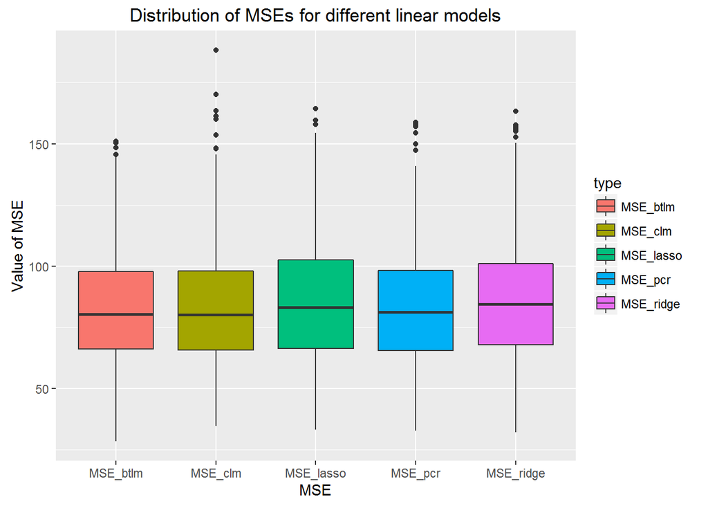

## 5) MOVING BEYOND LINEARITY

### 5.1) Regression trees

With cross validation, we see that the deviance is minimized with a number of leaves equal to 12, so we don’t have the necessity to prune the original tree.  
As we see from the summary and the plot, the variables used by this model are only *Population*, *Gender Population*, *Age Range* and *Region*.

```
##
## Regression tree:
## tree(formula = new ~ ., data = data_model1)
## Variables actually used in tree construction:
## [1] "Population"        "Gender.Population" "AGE_GROUP"
## [4] "region"
## Number of terminal nodes:  12
## Residual mean deviance:  38.69 = 221000 / 5714
## Distribution of residuals:
##     Min.  1st Qu.   Median     Mean  3rd Qu.     Max.
## -61.4200  -2.7700  -0.7703   0.0000   2.2300  67.0800
```

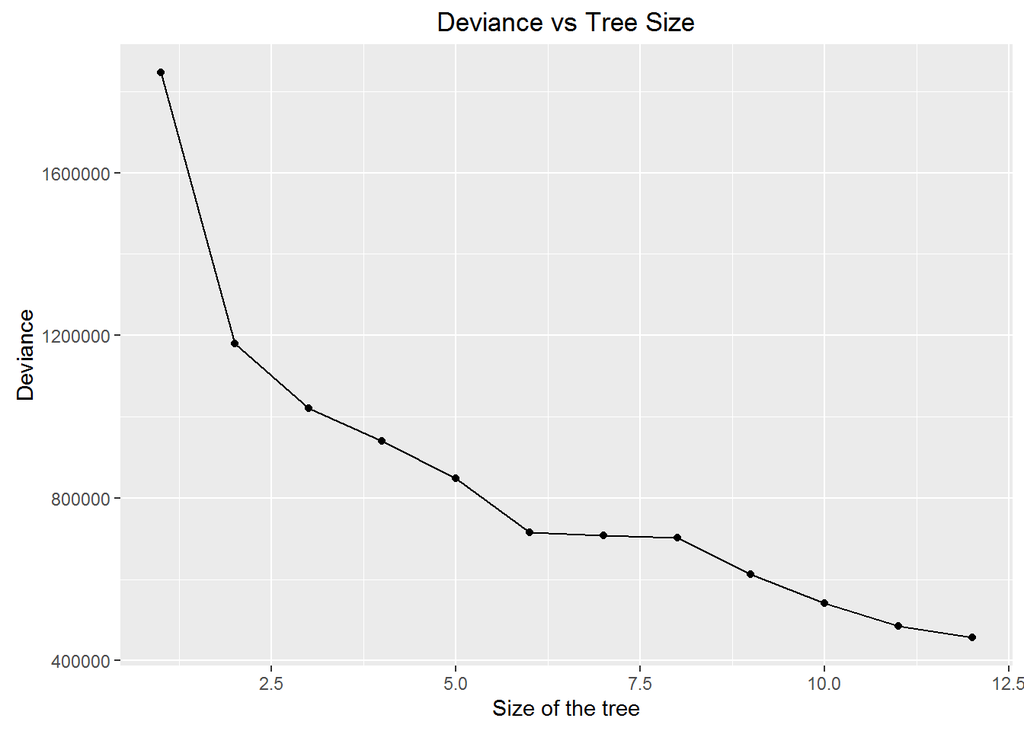

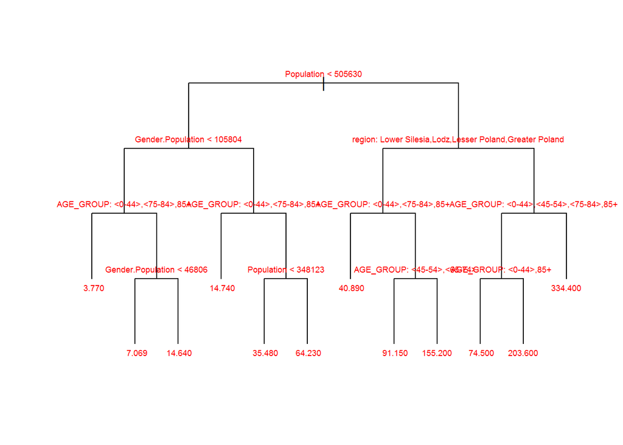

### 5.2) Bagging

```
##
## Call:
##  randomForest(formula = new ~ ., data = data_model1, mtry = 6,      importance = TRUE)
##                Type of random forest: regression
##                      Number of trees: 500
## No. of variables tried at each split: 6
##
##           Mean of squared residuals: 16.61582
##                     % Var explained: 94.85
```

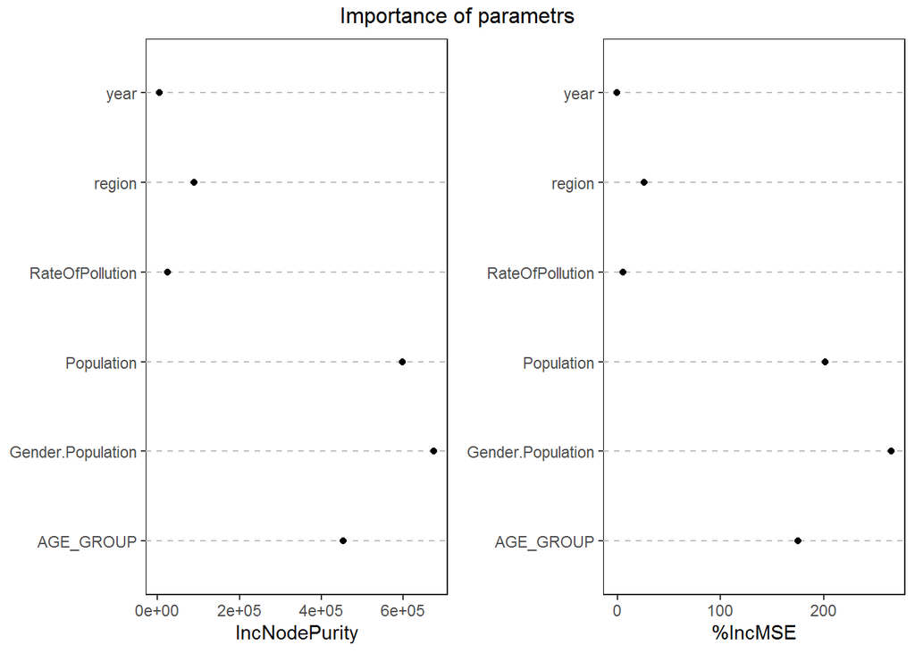

### 5.3) Boosting

While bagging and random forests use bootstrap to build tree independently one from the other, boosting uses the same procedure but the trees are grown sequentially, so each tree is grown using information from previously grown trees.  
We selected a value for the number of trees equal to 5000 (aware that value too big could lead to overfitting), a shrinkage parameter equal to 0.1, and interaction depth equal to 6 that is the number of variables.  
We reported here the influence of each variable in the model; as we previously saw, the most important are *Population*, *Gender Population* and *Age Range*.

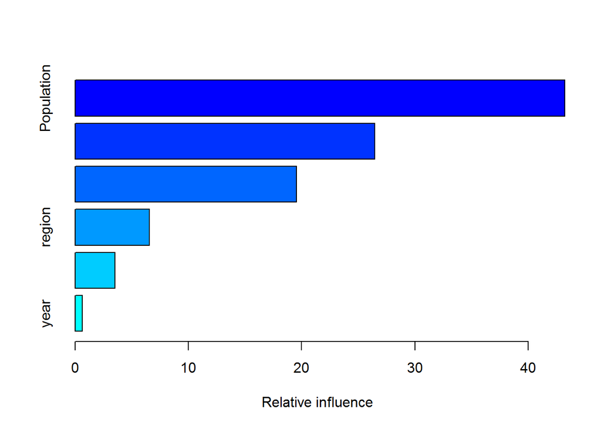

```
##                                 var    rel.inf
## Population               Population 43.2396329
## Gender.Population Gender.Population 26.4581433
## AGE_GROUP                 AGE_GROUP 19.5645497
## region                       region  6.5644085
## RateOfPollution     RateOfPollution  3.5187994
## year                           year  0.6544662
```

Here we present the distribution of MSEs for these three methods:

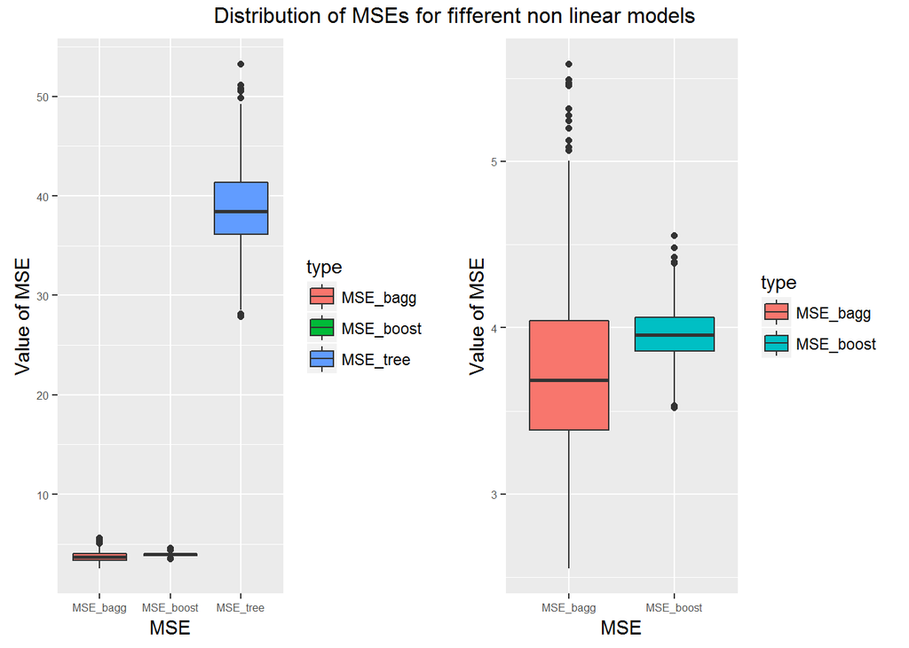

## 6) CONCLUSIONS

In this final table, we summarized what we’ve found for the different models. Its clear that linear models perform in a worse way than non linear ones. In particular we notice that the **BAGGING** and **BOOSTING** method appears to work significantly well, so our final decision is to use them for the predction of new breast cancers.

```
##                                  Model         MSE_mean            MSE_sd
## 1                complete linear model  82.820441431405  23.8946825138729
## 2 linear model with stepwise selection 82.3207637129204  23.4534957088214
## 3                                ridge 85.6361899076727  24.1965165193918
## 4                                lasso 85.2197017982906  24.6102586718587
## 5       principal component regression 82.3967735436881  23.1863207537971
## 6                                 tree 38.7748757456621   3.9952366872806
## 7                              bagging 3.73095025427512 0.492942880369974
## 8                             boosting 3.96271364485943 0.159291447679968
```

## Apendix

### Data preparation

```r
dt<- read.csv2("dane_podstawowe_ICD.csv")


row_delete_M <- which((dt$ICD10== "C53"|dt$ICD10== "C54"| dt$ICD10=="C56") & (dt$PLEC=="M"))
dt1<-dt[-row_delete_M,]
row_delete_K <- which((dt1$ICD10== "C61"|dt1$ICD10== "C62") & (dt1$PLEC=="K"))
dt2<-dt1[-row_delete_K,]

library("PogromcyDanych")
dt3<- dt2 %>%
  group_by(ICD10, PLEC, grupa_wiek, TERYT4, woj, pow, rok) %>%
    summarise(Stage1 = sum(Stage1),
            Stage2 = sum(Stage2),
            Stage3 = sum(Stage3),
            Stage4 = sum(Stage4))

dt3$new<-dt3$Stage1 +dt3$Stage2 +dt3$Stage3 +dt3$Stage4

dt3$CancerGroup<-1

HandN <- which(dt3$ICD10== "C00"|dt3$ICD10== "C01_C02_C03_C04_C05_C06_C09_C10_C14"|
                  dt3$ICD10=="C07_C08" |dt3$ICD10=="C11_C12_C13_C30_C31")
dt3[HandN,]$CancerGroup<-"Malignant neoplasms of head and neck cancer"

deOrg <- which(dt3$ICD10== "C15"|dt3$ICD10== "C16_C26"| dt3$ICD10== "C25"|
                 dt3$ICD10=="C20_C21" |dt3$ICD10=="C22" |dt3$ICD10=="C23_C24" |dt3$ICD10== "C18_C19")
dt3[deOrg,]$CancerGroup<-"Malignant neoplasms of digestive organs"

RandI <- which(dt3$ICD10== "C32"|dt3$ICD10== "C33_C34"| dt3$ICD10== "C43")
dt3[RandI,]$CancerGroup<-"Malignant neoplasms of respiratory and intrathoracic organs"

NofB <- which(dt3$ICD10== "C50_D05")
dt3[NofB,]$CancerGroup<-"Malignant neoplasm of breast"

FGO <- which(dt3$ICD10== "C53"|dt3$ICD10== "C54"| dt3$ICD10== "C56")
dt3[FGO,]$CancerGroup<-"Malignant neoplasms of female genital organs"

MGO <- which(dt3$ICD10== "C61"|dt3$ICD10== "C62")
dt3[MGO,]$CancerGroup<-"Malignant neoplasms of male genital organs"

NofUT <- which(dt3$ICD10== "C64_C65_C66"|dt3$ICD10== "C67")
dt3[NofUT,]$CancerGroup<-"Malignant neoplasms of urinary tract"

CNS <- which(dt3$ICD10== "C70_C71_C72")
dt3[CNS,]$CancerGroup<-"Malignant neoplasms of eye, brain and other parts of central nervous system"

TG <- which(dt3$ICD10== "C73")
dt3[TG,]$CancerGroup<-"Malignant neoplasm of thyroid gland"

dt3$CancerSex<-"Both"

M <- which(dt3$CancerGroup== "Malignant neoplasms of male genital organs")
dt3[M,]$CancerSex<-"Men"

K <- which(dt3$CancerGroup== "Malignant neoplasms of female genital organs")
dt3[K,]$CancerSex<-"Female"

dt_ACT<-as.data.frame(dt3)

save(dt_ACT,file="dataCancer.Rda")

DT_ACT<-load("dataCancer.Rda")
```

[figure not shown]